# HRS 2016 - Cognition classification

Author

Doug Tommet

Published

December 18, 2024

# Data

The data used in this analysis comes from the 2016 wave of the HRS study. The data was directly downloaded from their website.

The files used are:

- `trk2022tr_r.dta`
- `H16A_R.dta`
- `H16D_R.dta`

To norm the factor scores, RNJ provided a dataset that identified the participants with normal cognition in the HCAP sample.

# Recode demographic variables

This section shows the recoding of the demographic variables.

Age came from the variable `PA019` and no recoding was done.

Years of education came from the variable `SCHLYRS` and no recoding was done. Five participants had their values changed based on RNJ’s code.

Female came from the variable `GENDER`.

Coding of female indicator

| Female from trk2022tr_r | GENDER | n |
| --- | --- | --- |
| 0 | 1. Male | 8664 |
| 1 | 2. Female | 12245 |
| NA | NA | 3 |

Black came from the variables `RACE` and `HISPANIC`.

Coding of Black or African-American indicator

| Black or African-American (not Hispanic) from trk2022tr_r | RACE | HISPANIC | n |
| --- | --- | --- | --- |
| 0 | 0. Not obtained | 0. Not obtained | 5 |
| 0 | 0. Not obtained | 1. Hispanic, Mexican | 40 |
| 0 | 0. Not obtained | 2. Hispanic, Other | 23 |
| 0 | 0. Not obtained | 3. Hispanic, type unknown | 1 |
| 0 | 0. Not obtained | 5. Non-Hispanic | 9 |
| 0 | 1. White/Caucasian | 0. Not obtained | 9 |
| 0 | 1. White/Caucasian | 1. Hispanic, Mexican | 1138 |
| 0 | 1. White/Caucasian | 2. Hispanic, Other | 677 |
| 0 | 1. White/Caucasian | 3. Hispanic, type unknown | 18 |
| 0 | 1. White/Caucasian | 5. Non-Hispanic | 11980 |
| 0 | 2. Black or African American | 1. Hispanic, Mexican | 10 |
| 0 | 2. Black or African American | 2. Hispanic, Other | 86 |
| 0 | 2. Black or African American | 3. Hispanic, type unknown | 2 |
| 0 | 7. Other | 0. Not obtained | 15 |
| 0 | 7. Other | 1. Hispanic, Mexican | 795 |
| 0 | 7. Other | 2. Hispanic, Other | 632 |
| 0 | 7. Other | 3. Hispanic, type unknown | 5 |
| 0 | 7. Other | 5. Non-Hispanic | 1030 |
| 1 | 2. Black or African American | 0. Not obtained | 12 |
| 1 | 2. Black or African American | 5. Non-Hispanic | 4422 |
| NA | NA | NA | 3 |

Hispanic came from the variable `HISPANIC`.

Coding of Hispanic indicator

| Hispanic from trk2022tr_r | HISPANIC | n |
| --- | --- | --- |
| 0 | 0. Not obtained | 41 |
| 0 | 5. Non-Hispanic | 17441 |
| 1 | 1. Hispanic, Mexican | 1983 |
| 1 | 2. Hispanic, Other | 1418 |
| 1 | 3. Hispanic, type unknown | 26 |
| NA | NA | 3 |

# Recode cognitive items

This section shows the recoding of the cognitive items.

In general, I tried to have higher values indicate correct or better performance.

I recoded “don’t know” and “refusal” to incorrect. These could be changed.

If all the component values of a vd variable are NA, then I set the vd variable to NA.

The tables show the recoded variable on the left column, the original variable in the center, and the sample size on the right column.

## Orientation

The number correct of the four orientation to time questions - Month, Day, Year and Day of week.

vdori - Orientation to time - number correct

| Orientation to Time - number correct | PD151 | PD152 | PD153 | PD154 | n |
| --- | --- | --- | --- | --- | --- |
| 0 | 5. MONTH NOT OK | 5. DAY OF MONTH NOT OK | 5. YEAR NOT OK | 5. DAY NOT OK | 34 |
| 0 | 5. MONTH NOT OK | 5. DAY OF MONTH NOT OK | 5. YEAR NOT OK | 8. DK (Don't Know) | 2 |
| 0 | 5. MONTH NOT OK | 5. DAY OF MONTH NOT OK | 8. DK (Don't Know) | 5. DAY NOT OK | 6 |
| 0 | 5. MONTH NOT OK | 5. DAY OF MONTH NOT OK | 8. DK (Don't Know) | 8. DK (Don't Know) | 1 |
| 0 | 5. MONTH NOT OK | 8. DK (Don't Know) | 5. YEAR NOT OK | 5. DAY NOT OK | 1 |
| 0 | 5. MONTH NOT OK | 8. DK (Don't Know) | 5. YEAR NOT OK | 8. DK (Don't Know) | 1 |
| 0 | 5. MONTH NOT OK | 8. DK (Don't Know) | 8. DK (Don't Know) | 5. DAY NOT OK | 5 |
| 0 | 5. MONTH NOT OK | 8. DK (Don't Know) | 8. DK (Don't Know) | 8. DK (Don't Know) | 2 |
| 0 | 8. DK (Don't Know) | 5. DAY OF MONTH NOT OK | 5. YEAR NOT OK | 5. DAY NOT OK | 2 |
| 0 | 8. DK (Don't Know) | 5. DAY OF MONTH NOT OK | 5. YEAR NOT OK | 8. DK (Don't Know) | 1 |
| 0 | 8. DK (Don't Know) | 5. DAY OF MONTH NOT OK | 8. DK (Don't Know) | 5. DAY NOT OK | 1 |
| 0 | 8. DK (Don't Know) | 8. DK (Don't Know) | 5. YEAR NOT OK | 5. DAY NOT OK | 4 |
| 0 | 8. DK (Don't Know) | 8. DK (Don't Know) | 5. YEAR NOT OK | 8. DK (Don't Know) | 1 |
| 0 | 8. DK (Don't Know) | 8. DK (Don't Know) | 8. DK (Don't Know) | 5. DAY NOT OK | 16 |
| 0 | 8. DK (Don't Know) | 8. DK (Don't Know) | 8. DK (Don't Know) | 8. DK (Don't Know) | 46 |
| 0 | 9. RF (Refused) | 9. RF (Refused) | 9. RF (Refused) | 5. DAY NOT OK | 1 |
| 0 | 9. RF (Refused) | 9. RF (Refused) | 9. RF (Refused) | 9. RF (Refused) | 14 |
| 1 | 1. MONTH OK | 5. DAY OF MONTH NOT OK | 5. YEAR NOT OK | 5. DAY NOT OK | 35 |
| 1 | 1. MONTH OK | 5. DAY OF MONTH NOT OK | 5. YEAR NOT OK | 8. DK (Don't Know) | 1 |
| 1 | 1. MONTH OK | 5. DAY OF MONTH NOT OK | 8. DK (Don't Know) | 5. DAY NOT OK | 3 |
| 1 | 1. MONTH OK | 5. DAY OF MONTH NOT OK | 8. DK (Don't Know) | 8. DK (Don't Know) | 1 |
| 1 | 1. MONTH OK | 5. DAY OF MONTH NOT OK | 9. RF (Refused) | 5. DAY NOT OK | 1 |
| 1 | 1. MONTH OK | 8. DK (Don't Know) | 5. YEAR NOT OK | 5. DAY NOT OK | 4 |
| 1 | 1. MONTH OK | 8. DK (Don't Know) | 5. YEAR NOT OK | 8. DK (Don't Know) | 3 |
| 1 | 1. MONTH OK | 8. DK (Don't Know) | 8. DK (Don't Know) | 5. DAY NOT OK | 3 |
| 1 | 1. MONTH OK | 8. DK (Don't Know) | 8. DK (Don't Know) | 8. DK (Don't Know) | 7 |
| 1 | 5. MONTH NOT OK | 1. DAY OF MONTH OK | 5. YEAR NOT OK | 5. DAY NOT OK | 5 |
| 1 | 5. MONTH NOT OK | 1. DAY OF MONTH OK | 8. DK (Don't Know) | 8. DK (Don't Know) | 2 |
| 1 | 5. MONTH NOT OK | 5. DAY OF MONTH NOT OK | 1. YEAR OK | 5. DAY NOT OK | 12 |
| 1 | 5. MONTH NOT OK | 5. DAY OF MONTH NOT OK | 1. YEAR OK | 8. DK (Don't Know) | 2 |
| 1 | 5. MONTH NOT OK | 5. DAY OF MONTH NOT OK | 5. YEAR NOT OK | 1. DAY OK | 39 |
| 1 | 5. MONTH NOT OK | 5. DAY OF MONTH NOT OK | 8. DK (Don't Know) | 1. DAY OK | 4 |
| 1 | 5. MONTH NOT OK | 8. DK (Don't Know) | 1. YEAR OK | 5. DAY NOT OK | 1 |
| 1 | 5. MONTH NOT OK | 8. DK (Don't Know) | 1. YEAR OK | 8. DK (Don't Know) | 1 |
| 1 | 5. MONTH NOT OK | 8. DK (Don't Know) | 5. YEAR NOT OK | 1. DAY OK | 3 |
| 1 | 5. MONTH NOT OK | 8. DK (Don't Know) | 8. DK (Don't Know) | 1. DAY OK | 6 |
| 1 | 8. DK (Don't Know) | 1. DAY OF MONTH OK | 5. YEAR NOT OK | 5. DAY NOT OK | 1 |
| 1 | 8. DK (Don't Know) | 1. DAY OF MONTH OK | 8. DK (Don't Know) | 8. DK (Don't Know) | 1 |
| 1 | 8. DK (Don't Know) | 5. DAY OF MONTH NOT OK | 1. YEAR OK | 8. DK (Don't Know) | 1 |
| 1 | 8. DK (Don't Know) | 5. DAY OF MONTH NOT OK | 8. DK (Don't Know) | 1. DAY OK | 1 |
| 1 | 8. DK (Don't Know) | 8. DK (Don't Know) | 1. YEAR OK | 5. DAY NOT OK | 2 |
| 1 | 8. DK (Don't Know) | 8. DK (Don't Know) | 1. YEAR OK | 8. DK (Don't Know) | 2 |
| 1 | 8. DK (Don't Know) | 8. DK (Don't Know) | 5. YEAR NOT OK | 1. DAY OK | 4 |
| 1 | 8. DK (Don't Know) | 8. DK (Don't Know) | 8. DK (Don't Know) | 1. DAY OK | 26 |
| 2 | 1. MONTH OK | 1. DAY OF MONTH OK | 5. YEAR NOT OK | 5. DAY NOT OK | 26 |
| 2 | 1. MONTH OK | 1. DAY OF MONTH OK | 5. YEAR NOT OK | 8. DK (Don't Know) | 2 |
| 2 | 1. MONTH OK | 1. DAY OF MONTH OK | 8. DK (Don't Know) | 5. DAY NOT OK | 2 |
| 2 | 1. MONTH OK | 1. DAY OF MONTH OK | 8. DK (Don't Know) | 8. DK (Don't Know) | 1 |
| 2 | 1. MONTH OK | 5. DAY OF MONTH NOT OK | 1. YEAR OK | 5. DAY NOT OK | 99 |
| 2 | 1. MONTH OK | 5. DAY OF MONTH NOT OK | 1. YEAR OK | 8. DK (Don't Know) | 10 |
| 2 | 1. MONTH OK | 5. DAY OF MONTH NOT OK | 5. YEAR NOT OK | 1. DAY OK | 71 |
| 2 | 1. MONTH OK | 5. DAY OF MONTH NOT OK | 8. DK (Don't Know) | 1. DAY OK | 12 |
| 2 | 1. MONTH OK | 8. DK (Don't Know) | 1. YEAR OK | 5. DAY NOT OK | 9 |
| 2 | 1. MONTH OK | 8. DK (Don't Know) | 1. YEAR OK | 8. DK (Don't Know) | 6 |
| 2 | 1. MONTH OK | 8. DK (Don't Know) | 5. YEAR NOT OK | 1. DAY OK | 6 |
| 2 | 1. MONTH OK | 8. DK (Don't Know) | 8. DK (Don't Know) | 1. DAY OK | 7 |
| 2 | 5. MONTH NOT OK | 1. DAY OF MONTH OK | 1. YEAR OK | 5. DAY NOT OK | 4 |
| 2 | 5. MONTH NOT OK | 1. DAY OF MONTH OK | 5. YEAR NOT OK | 1. DAY OK | 10 |
| 2 | 5. MONTH NOT OK | 1. DAY OF MONTH OK | 8. DK (Don't Know) | 1. DAY OK | 2 |
| 2 | 5. MONTH NOT OK | 5. DAY OF MONTH NOT OK | 1. YEAR OK | 1. DAY OK | 111 |
| 2 | 5. MONTH NOT OK | 8. DK (Don't Know) | 1. YEAR OK | 1. DAY OK | 7 |
| 2 | 8. DK (Don't Know) | 1. DAY OF MONTH OK | 1. YEAR OK | 8. DK (Don't Know) | 1 |
| 2 | 8. DK (Don't Know) | 1. DAY OF MONTH OK | 5. YEAR NOT OK | 1. DAY OK | 3 |
| 2 | 8. DK (Don't Know) | 1. DAY OF MONTH OK | 8. DK (Don't Know) | 1. DAY OK | 3 |
| 2 | 8. DK (Don't Know) | 5. DAY OF MONTH NOT OK | 1. YEAR OK | 1. DAY OK | 9 |
| 2 | 8. DK (Don't Know) | 8. DK (Don't Know) | 1. YEAR OK | 1. DAY OK | 19 |
| 3 | 1. MONTH OK | 1. DAY OF MONTH OK | 1. YEAR OK | 5. DAY NOT OK | 189 |
| 3 | 1. MONTH OK | 1. DAY OF MONTH OK | 1. YEAR OK | 8. DK (Don't Know) | 15 |
| 3 | 1. MONTH OK | 1. DAY OF MONTH OK | 5. YEAR NOT OK | 1. DAY OK | 136 |
| 3 | 1. MONTH OK | 1. DAY OF MONTH OK | 8. DK (Don't Know) | 1. DAY OK | 16 |
| 3 | 1. MONTH OK | 5. DAY OF MONTH NOT OK | 1. YEAR OK | 1. DAY OK | 1834 |
| 3 | 1. MONTH OK | 8. DK (Don't Know) | 1. YEAR OK | 1. DAY OK | 137 |
| 3 | 1. MONTH OK | 9. RF (Refused) | 1. YEAR OK | 1. DAY OK | 1 |
| 3 | 5. MONTH NOT OK | 1. DAY OF MONTH OK | 1. YEAR OK | 1. DAY OK | 144 |
| 3 | 8. DK (Don't Know) | 1. DAY OF MONTH OK | 1. YEAR OK | 1. DAY OK | 9 |
| 4 | 1. MONTH OK | 1. DAY OF MONTH OK | 1. YEAR OK | 1. DAY OK | 10490 |
| NA | NA | NA | NA | NA | 7212 |

| **Characteristic** | **N = 20,912**<sup>1</sup> |
| --- | --- |
| Orientation to Time - number correct |  |
| 0 | 138 (1.0%) |
| 1 | 171 (1.2%) |
| 2 | 420 (3.1%) |
| 3 | 2,481 (18%) |
| 4 | 10,490 (77%) |
| Unknown | 7,212 |

<sup>1</sup> n (%)

## Count backwards

vdcount: Count backwards

| Count backwards from 20 | PD124 | PD129 | n |
| --- | --- | --- | --- |
| 0 | 5. INCORRECT | NA | 1324 |
| 0 | 6. WANTS TO START OVER | 5. INCORRECT | 11 |
| 0 | 6. WANTS TO START OVER | 9. RF (Refused) | 2 |
| 0 | 9. RF (Refused) | NA | 20 |
| 1 | 1. CORRECT | NA | 18519 |
| 1 | 6. WANTS TO START OVER | 1. CORRECT | 35 |
| NA | NA | NA | 1001 |

| **Characteristic** | **N = 20,912**<sup>1</sup> |
| --- | --- |
| Count backwards from 20 |  |
| Correct | 18,554 (93%) |
| Incorrect | 1,357 (6.8%) |
| Unknown | 1,001 |

<sup>1</sup> n (%)

## Object naming

The scissors and cactus naming items have been combined into one item.

vdlfl2: Scissors & Cactus - number correct

| Object naming - Scissors, cactus | PD155 | PD156 | n |
| --- | --- | --- | --- |
| 0 | 5. NOT CORRECT | 5. NOT CORRECT | 20 |
| 0 | 5. NOT CORRECT | 8. DK (Don't Know) | 20 |
| 0 | 5. NOT CORRECT | 9. RF (Refused) | 1 |
| 0 | 8. DK (Don't Know) | 5. NOT CORRECT | 9 |
| 0 | 8. DK (Don't Know) | 8. DK (Don't Know) | 27 |
| 0 | 9. RF (Refused) | 9. RF (Refused) | 17 |
| 1 | 1. SCISSORS OR SHEARS ONLY | 5. NOT CORRECT | 367 |
| 1 | 1. SCISSORS OR SHEARS ONLY | 8. DK (Don't Know) | 643 |
| 1 | 1. SCISSORS OR SHEARS ONLY | 9. RF (Refused) | 4 |
| 1 | 5. NOT CORRECT | 1. CACTUS OR NAME OF KIND OF CACTUS | 99 |
| 1 | 8. DK (Don't Know) | 1. CACTUS OR NAME OF KIND OF CACTUS | 28 |
| 1 | 9. RF (Refused) | 1. CACTUS OR NAME OF KIND OF CACTUS | 3 |
| 2 | 1. SCISSORS OR SHEARS ONLY | 1. CACTUS OR NAME OF KIND OF CACTUS | 12462 |
| NA | NA | NA | 7212 |

| **Characteristic** | **N = 20,912**<sup>1</sup> |
| --- | --- |
| Object naming - Scissors, cactus |  |
| 0 | 94 (0.7%) |
| 1 | 1,144 (8.4%) |
| 2 | 12,462 (91%) |
| Unknown | 7,212 |

<sup>1</sup> n (%)

## President/Vice-president

The president and vice-president naming items have been combined into one item.

vdlfl3: President and vice-president - number correct

| Naming - President, Vice-president | PD157 | PD158 | n |
| --- | --- | --- | --- |
| 0 | 5. NOT CORRECT | 5. NOT CORRECT | 51 |
| 0 | 5. NOT CORRECT | 8. DK (Don't Know) | 45 |
| 0 | 8. DK (Don't Know) | 5. NOT CORRECT | 11 |
| 0 | 8. DK (Don't Know) | 8. DK (Don't Know) | 241 |
| 0 | 8. DK (Don't Know) | 9. RF (Refused) | 1 |
| 0 | 9. RF (Refused) | 8. DK (Don't Know) | 4 |
| 0 | 9. RF (Refused) | 9. RF (Refused) | 23 |
| 1 | 1. LAST NAME CORRECT | 5. NOT CORRECT | 1343 |
| 1 | 1. LAST NAME CORRECT | 8. DK (Don't Know) | 3347 |
| 1 | 1. LAST NAME CORRECT | 9. RF (Refused) | 15 |
| 1 | 5. NOT CORRECT | 1. LAST NAME CORRECT | 14 |
| 1 | 8. DK (Don't Know) | 1. LAST NAME CORRECT | 15 |
| 1 | 9. RF (Refused) | 1. LAST NAME CORRECT | 4 |
| 2 | 1. LAST NAME CORRECT | 1. LAST NAME CORRECT | 8585 |
| NA | NA | NA | 7213 |

| **Characteristic** | **N = 20,912**<sup>1</sup> |
| --- | --- |
| Naming - President, Vice-president |  |
| 0 | 376 (2.7%) |
| 1 | 4,738 (35%) |
| 2 | 8,585 (63%) |
| Unknown | 7,213 |

<sup>1</sup> n (%)

## Serial 7

The new variable counts the number of correct responses on the serial 7. Each item was checked so that the difference between consecutive items is 7. So if a mistake was made early on, there is an opportunity to get the remaining items correct.

PD142-PD146: Serial 7

| Serial 7's - Number correct | rPD142 | rPD143 | rPD144 | rPD145 | rPD146 | n |
| --- | --- | --- | --- | --- | --- | --- |
| 0 | 0. Incorrect | 0. Incorrect | 0. Incorrect | 0. Incorrect | 0. Incorrect | 406 |
| 0 | 0. Incorrect | 0. Incorrect | 0. Incorrect | 0. Incorrect | NA | 43 |
| 0 | 0. Incorrect | 0. Incorrect | 0. Incorrect | NA | NA | 116 |
| 0 | 0. Incorrect | 0. Incorrect | NA | NA | NA | 266 |
| 0 | 0. Incorrect | NA | NA | NA | NA | 1014 |
| 1 | 0. Incorrect | 0. Incorrect | 0. Incorrect | 0. Incorrect | 1. Correct | 58 |
| 1 | 0. Incorrect | 0. Incorrect | 0. Incorrect | 1. Correct | 0. Incorrect | 69 |
| 1 | 0. Incorrect | 0. Incorrect | 1. Correct | 0. Incorrect | 0. Incorrect | 68 |
| 1 | 0. Incorrect | 0. Incorrect | 1. Correct | 0. Incorrect | NA | 13 |
| 1 | 0. Incorrect | 1. Correct | 0. Incorrect | 0. Incorrect | 0. Incorrect | 91 |
| 1 | 0. Incorrect | 1. Correct | 0. Incorrect | 0. Incorrect | NA | 14 |
| 1 | 0. Incorrect | 1. Correct | 0. Incorrect | NA | NA | 31 |
| 1 | 1. Correct | 0. Incorrect | 0. Incorrect | 0. Incorrect | 0. Incorrect | 698 |
| 1 | 1. Correct | 0. Incorrect | 0. Incorrect | 0. Incorrect | NA | 82 |
| 1 | 1. Correct | 0. Incorrect | 0. Incorrect | NA | NA | 235 |
| 1 | 1. Correct | 0. Incorrect | NA | NA | NA | 754 |
| 2 | 0. Incorrect | 0. Incorrect | 0. Incorrect | 1. Correct | 1. Correct | 36 |
| 2 | 0. Incorrect | 0. Incorrect | 1. Correct | 0. Incorrect | 1. Correct | 48 |
| 2 | 0. Incorrect | 0. Incorrect | 1. Correct | 1. Correct | 0. Incorrect | 49 |
| 2 | 0. Incorrect | 1. Correct | 0. Incorrect | 0. Incorrect | 1. Correct | 24 |
| 2 | 0. Incorrect | 1. Correct | 0. Incorrect | 1. Correct | 0. Incorrect | 42 |
| 2 | 0. Incorrect | 1. Correct | 1. Correct | 0. Incorrect | 0. Incorrect | 46 |
| 2 | 0. Incorrect | 1. Correct | 1. Correct | 0. Incorrect | NA | 18 |
| 2 | 1. Correct | 0. Incorrect | 0. Incorrect | 0. Incorrect | 1. Correct | 295 |
| 2 | 1. Correct | 0. Incorrect | 0. Incorrect | 1. Correct | 0. Incorrect | 266 |
| 2 | 1. Correct | 0. Incorrect | 1. Correct | 0. Incorrect | 0. Incorrect | 249 |
| 2 | 1. Correct | 0. Incorrect | 1. Correct | 0. Incorrect | NA | 52 |
| 2 | 1. Correct | 1. Correct | 0. Incorrect | 0. Incorrect | 0. Incorrect | 327 |
| 2 | 1. Correct | 1. Correct | 0. Incorrect | 0. Incorrect | NA | 67 |
| 2 | 1. Correct | 1. Correct | 0. Incorrect | NA | NA | 179 |
| 3 | 0. Incorrect | 0. Incorrect | 1. Correct | 1. Correct | 1. Correct | 72 |
| 3 | 0. Incorrect | 1. Correct | 0. Incorrect | 1. Correct | 1. Correct | 36 |
| 3 | 0. Incorrect | 1. Correct | 1. Correct | 0. Incorrect | 1. Correct | 26 |
| 3 | 0. Incorrect | 1. Correct | 1. Correct | 1. Correct | 0. Incorrect | 52 |
| 3 | 1. Correct | 0. Incorrect | 0. Incorrect | 1. Correct | 1. Correct | 553 |
| 3 | 1. Correct | 0. Incorrect | 1. Correct | 0. Incorrect | 1. Correct | 274 |
| 3 | 1. Correct | 0. Incorrect | 1. Correct | 1. Correct | 0. Incorrect | 633 |
| 3 | 1. Correct | 1. Correct | 0. Incorrect | 0. Incorrect | 1. Correct | 333 |
| 3 | 1. Correct | 1. Correct | 0. Incorrect | 1. Correct | 0. Incorrect | 389 |
| 3 | 1. Correct | 1. Correct | 1. Correct | 0. Incorrect | 0. Incorrect | 264 |
| 3 | 1. Correct | 1. Correct | 1. Correct | 0. Incorrect | NA | 44 |
| 4 | 0. Incorrect | 1. Correct | 1. Correct | 1. Correct | 1. Correct | 107 |
| 4 | 1. Correct | 0. Incorrect | 1. Correct | 1. Correct | 1. Correct | 1417 |
| 4 | 1. Correct | 1. Correct | 0. Incorrect | 1. Correct | 1. Correct | 871 |
| 4 | 1. Correct | 1. Correct | 1. Correct | 0. Incorrect | 1. Correct | 493 |
| 4 | 1. Correct | 1. Correct | 1. Correct | 1. Correct | 0. Incorrect | 851 |
| 5 | 1. Correct | 1. Correct | 1. Correct | 1. Correct | 1. Correct | 7899 |
| NA | NA | NA | NA | NA | NA | 942 |

| **Characteristic** | **N = 20,912**<sup>1</sup> |
| --- | --- |
| Serial 7's - Number correct |  |
| 0 | 1,845 (9.2%) |
| 1 | 2,113 (11%) |
| 2 | 1,698 (8.5%) |
| 3 | 2,676 (13%) |
| 4 | 3,739 (19%) |
| 5 | 7,899 (40%) |
| Unknown | 942 |

<sup>1</sup> n (%)

## Animal naming

This variable is the number of correct responses minus the number of errors. Missing values are set at the median value of errors.

PD196: Animal naming

| Animal naming (correct - errors) | TOTAL ANIMALS ANSWERS | ANIMAL MISTAKES NUMBER | n |
| --- | --- | --- | --- |
| 0 | 0 | NA | 12 |
| 0 | 1 | 3 | 1 |
| 0 | 1 | NA | 18 |
| 0 | 2 | 2 | 1 |
| 0 | 3 | 3 | 2 |
| 0 | 6 | 7 | 1 |
| 0 | 7 | 18 | 1 |
| 0 | 8 | 15 | 1 |
| 0 | 8 | 16 | 1 |
| 0 | 9 | 10 | 2 |
| 0 | 10 | 10 | 1 |
| 0 | 10 | 11 | 1 |
| 0 | 11 | 11 | 1 |
| 0 | 12 | 15 | 1 |
| 0 | 13 | 15 | 1 |
| 0 | 13 | 24 | 1 |
| 0 | 14 | 14 | 1 |
| 0 | 14 | 17 | 1 |
| 0 | 15 | 15 | 1 |
| 0 | 15 | 22 | 1 |
| 0 | 16 | 22 | 1 |
| 0 | 17 | 21 | 1 |
| 0 | 17 | 24 | 1 |
| 0 | 17 | 29 | 1 |
| 0 | 17 | 87 | 1 |
| 0 | 18 | 20 | 1 |
| 0 | 18 | 22 | 1 |
| 0 | 20 | 25 | 1 |
| 0 | 20 | 37 | 1 |
| 0 | 21 | 55 | 1 |

[output cut: 335 more lines]

| **Characteristic** | **N = 20,912**<sup>1</sup> |
| --- | --- |
| Animal naming (correct - errors) |  |
| 0 | 68 (0.5%) |
| 1 | 35 (0.3%) |
| 2 | 70 (0.5%) |
| 3 | 109 (0.8%) |
| 4 | 162 (1.2%) |
| 5 | 257 (1.9%) |
| 6 | 335 (2.5%) |
| 7 | 396 (2.9%) |
| 8 | 504 (3.7%) |
| 9 | 511 (3.8%) |
| 10 | 621 (4.6%) |
| 11 | 657 (4.8%) |
| 12 | 697 (5.1%) |
| 13 | 693 (5.1%) |
| 14 | 763 (5.6%) |
| 15 | 745 (5.5%) |
| 16 | 756 (5.6%) |
| 17 | 683 (5.0%) |
| 18 | 690 (5.1%) |
| 19 | 667 (4.9%) |
| 20 | 635 (4.7%) |
| 21 | 534 (3.9%) |
| 22 | 488 (3.6%) |
| 23 | 451 (3.3%) |
| 24 | 411 (3.0%) |
| 25 | 304 (2.2%) |
| 26 | 287 (2.1%) |
| 27 | 228 (1.7%) |
| 28 | 182 (1.3%) |
| 29 | 143 (1.1%) |
| 30 | 91 (0.7%) |
| 31 | 74 (0.5%) |
| 32 | 71 (0.5%) |
| 33 | 63 (0.5%) |
| 34 | 41 (0.3%) |
| 35 | 35 (0.3%) |
| 36 | 20 (0.1%) |
| 37 | 19 (0.1%) |
| 38 | 14 (0.1%) |
| 39 | 8 (<0.1%) |
| 40 | 4 (<0.1%) |
| 41 | 4 (<0.1%) |
| 42 | 9 (<0.1%) |
| 43 | 2 (<0.1%) |
| 44 | 2 (<0.1%) |
| 45 | 4 (<0.1%) |
| 46 | 2 (<0.1%) |
| 47 | 2 (<0.1%) |
| 49 | 1 (<0.1%) |
| 51 | 1 (<0.1%) |
| 56 | 1 (<0.1%) |
| 86 | 1 (<0.1%) |
| 88 | 2 (<0.1%) |
| Unknown | 7,359 |

<sup>1</sup> n (%)

## Word recall

I found two variables PD174 and PD184 that are the number of words recalled correctly, so we don’t need to recreate these scores with PD182M1-PD182M13 and PD183M1-PD183M13.

No recoding was done.

Are we going to use both immediate and delayed recall? Or just delayed recall?

vdwdimm: Immediate word recall

| Word recall - Immediate | NUMBER GOOD - IMMEDIATE | n |
| --- | --- | --- |
| 0 | 0 | 181 |
| 1 | 1 | 172 |
| 2 | 2 | 600 |
| 3 | 3 | 1574 |
| 4 | 4 | 3321 |
| 5 | 5 | 4712 |
| 6 | 6 | 4534 |
| 7 | 7 | 2912 |
| 8 | 8 | 1324 |
| 9 | 9 | 426 |
| 10 | 10 | 109 |
| NA | NA | 1047 |

| **Characteristic** | **N = 20,912**<sup>1</sup> |
| --- | --- |
| Word recall - Immediate |  |
| 0 | 181 (0.9%) |
| 1 | 172 (0.9%) |
| 2 | 600 (3.0%) |
| 3 | 1,574 (7.9%) |
| 4 | 3,321 (17%) |
| 5 | 4,712 (24%) |
| 6 | 4,534 (23%) |
| 7 | 2,912 (15%) |
| 8 | 1,324 (6.7%) |
| 9 | 426 (2.1%) |
| 10 | 109 (0.5%) |
| Unknown | 1,047 |

<sup>1</sup> n (%)

vdwddel: Delayed word recall

| Word recall - Delayed | NUMBER GOOD - DELAYED | n |
| --- | --- | --- |
| 0 | 0 | 1255 |
| 1 | 1 | 815 |
| 2 | 2 | 1517 |
| 3 | 3 | 2847 |
| 4 | 4 | 3986 |
| 5 | 5 | 4107 |
| 6 | 6 | 2942 |
| 7 | 7 | 1472 |
| 8 | 8 | 627 |
| 9 | 9 | 234 |
| 10 | 10 | 62 |
| NA | NA | 1048 |

| **Characteristic** | **N = 20,912**<sup>1</sup> |
| --- | --- |
| Word recall - Delayed |  |
| 0 | 1,255 (6.3%) |
| 1 | 815 (4.1%) |
| 2 | 1,517 (7.6%) |
| 3 | 2,847 (14%) |
| 4 | 3,986 (20%) |
| 5 | 4,107 (21%) |
| 6 | 2,942 (15%) |
| 7 | 1,472 (7.4%) |
| 8 | 627 (3.2%) |
| 9 | 234 (1.2%) |
| 10 | 62 (0.3%) |
| Unknown | 1,048 |

<sup>1</sup> n (%)

## Numeracy

Recoded 996, 997, and 999 as missing.

vdexf7: Number series score

| Number series | CALCULATED NUMBER SERIES SCORE | n |
| --- | --- | --- |
| 409 | 409 | 159 |
| 413 | 413 | 124 |
| 429 | 429 | 226 |
| 435 | 435 | 112 |
| 462 | 462 | 424 |
| 465 | 465 | 279 |
| 484 | 484 | 251 |
| 485 | 485 | 216 |
| 488 | 488 | 97 |
| 489 | 489 | 862 |
| 501 | 501 | 1132 |
| 503 | 503 | 1069 |
| 513 | 513 | 1058 |
| 514 | 514 | 830 |
| 518 | 518 | 1028 |
| 519 | 519 | 809 |
| 524 | 524 | 376 |
| 525 | 525 | 375 |
| 528 | 528 | 720 |
| 529 | 529 | 897 |
| 536 | 536 | 1254 |
| 537 | 537 | 1430 |
| 546 | 546 | 984 |
| 547 | 547 | 229 |
| 549 | 549 | 714 |
| 558 | 558 | 937 |
| 567 | 567 | 519 |
| 570 | 570 | 285 |
| 584 | 584 | 449 |
| NA | 996 | 945 |
| NA | 997 | 915 |
| NA | 999 | 258 |
| NA | NA | 949 |

| **Characteristic** | **N = 20,912**<sup>1</sup> |
| --- | --- |
| Number series |  |
| 409 | 159 (0.9%) |
| 413 | 124 (0.7%) |
| 429 | 226 (1.3%) |
| 435 | 112 (0.6%) |
| 462 | 424 (2.4%) |
| 465 | 279 (1.6%) |
| 484 | 251 (1.4%) |
| 485 | 216 (1.2%) |
| 488 | 97 (0.5%) |
| 489 | 862 (4.8%) |
| 501 | 1,132 (6.3%) |
| 503 | 1,069 (6.0%) |
| 513 | 1,058 (5.9%) |
| 514 | 830 (4.7%) |
| 518 | 1,028 (5.8%) |
| 519 | 809 (4.5%) |
| 524 | 376 (2.1%) |
| 525 | 375 (2.1%) |
| 528 | 720 (4.0%) |
| 529 | 897 (5.0%) |
| 536 | 1,254 (7.0%) |
| 537 | 1,430 (8.0%) |
| 546 | 984 (5.5%) |
| 547 | 229 (1.3%) |
| 549 | 714 (4.0%) |
| 558 | 937 (5.3%) |
| 567 | 519 (2.9%) |
| 570 | 285 (1.6%) |
| 584 | 449 (2.5%) |
| Unknown | 3,067 |

<sup>1</sup> n (%)

# Rescale cognitive items

The continuous cognitive items were rescaled using the min/max normalization.

Descriptive statistics of cognitive items after rescaling

| **Characteristic** | **N = 20,912** |
| --- | --- |
| Animal naming (correct - errors) |  |
| N Non-missing | 13,553 |
| Mean (SD) | 0.18 (0.08) |
| Median (Q1, Q3) | 0.18 (0.13, 0.24) |
| Min, Max | 0.00, 1.00 |
| Unknown | 7,359 |
| Word recall - Immediate |  |
| N Non-missing | 19,865 |
| Mean (SD) | 0.53 (0.17) |
| Median (Q1, Q3) | 0.50 (0.40, 0.60) |
| Min, Max | 0.00, 1.00 |
| Unknown | 1,047 |
| Word recall - Delayed |  |
| N Non-missing | 19,864 |
| Mean (SD) | 0.43 (0.20) |
| Median (Q1, Q3) | 0.40 (0.30, 0.60) |
| Min, Max | 0.00, 1.00 |
| Unknown | 1,048 |
| Number series |  |
| N Non-missing | 17,845 |
| Mean (SD) | 0.64 (0.18) |
| Median (Q1, Q3) | 0.66 (0.54, 0.73) |
| Min, Max | 0.00, 1.00 |
| Unknown | 3,067 |

# Model results

A single factor CFA model was fit to the items.

## Model 1

The first model used all the items.

The model fit for this model was “poor”.

| Fit statistic | Value |
| --- | --- |
| RMSEA : Estimate | 0.087 |
| CFI | 0.903 |
| SRMR | 0.057 |

| Item | Label | Std Factor Loading |
| --- | --- | --- |
| vdori | Orientation to time | 0.484 |
| vdlfl1z | Animal naming | 0.593 |
| vdlfl2 | Scissors & cactus | 0.661 |
| vdlfl3 | President & vice-president | 0.581 |
| vdwdimmz | Immediate word recall | 0.686 |
| vdwddelz | Delayed word recall | 0.681 |
| vdexf7z | Number series | 0.613 |
| vdsevens | Serial sevens | 0.664 |
| vdcount | Count backwards from 20 | 0.545 |

## Model 2

The second model removed the immediate word recall item.

The model fit for this model was “good”.

| Fit statistic | Value |
| --- | --- |
| RMSEA : Estimate | 0.057 |
| CFI | 0.961 |
| SRMR | 0.041 |

| Item | Label | Std Factor Loading |
| --- | --- | --- |
| vdori | Orientation to time | 0.485 |
| vdlfl1z | Animal naming | 0.591 |
| vdlfl2 | Scissors & cactus | 0.678 |
| vdlfl3 | President & vice-president | 0.599 |
| vdwddelz | Delayed word recall | 0.589 |
| vdexf7z | Number series | 0.642 |
| vdsevens | Serial sevens | 0.706 |
| vdcount | Count backwards from 20 | 0.567 |

### Factor scores

This is the distribution of the factor scores from the final model.

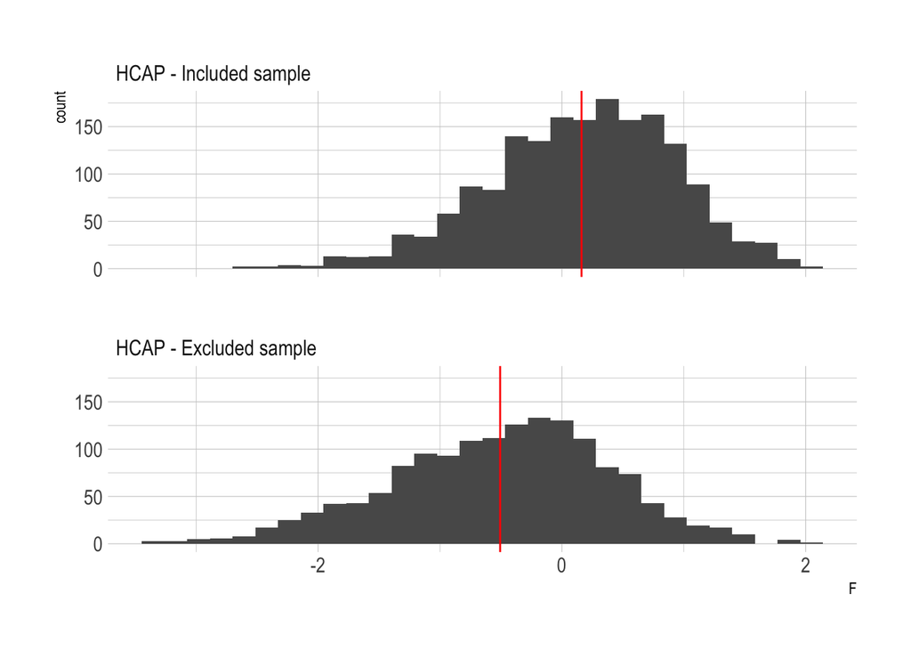

Distribution of factor scores by HCAP inclusion status

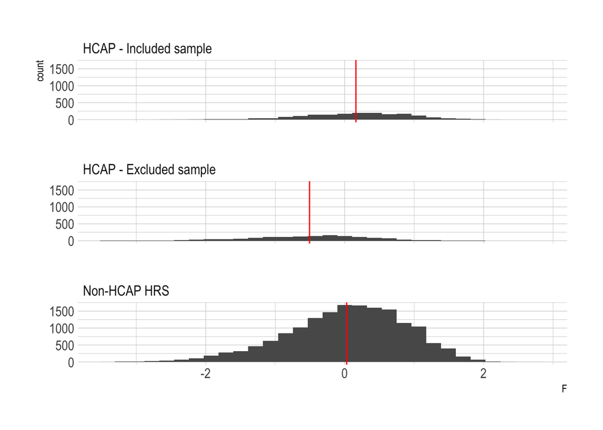

Distribution of factor scores by HCAP inclusion status, including HRS sample

# Norming the factor score

The HRS sample was filtered to those that were used as the norming sample in HCAP.

The demographic variables were centered to the mean values in the norming sample. The same centering values were used in the full HRS sample.

These are the centering values used:

| variable | mean |
| --- | --- |
| female | 0.601 |
| black | 0.148 |
| hisp | 0.100 |
| SCHLYRS | 13.329 |

Summary of the centered demographic variables in the norming sample:

| **Characteristic** | **N = 1,787**<sup>1</sup> |
| --- | --- |
| Female (centered to HCAP normal sample) |  |
| -0.601007274762171 | 713 / 1,787 (40%) |
| 0.398992725237829 | 1,074 / 1,787 (60%) |
| Black (centered to HCAP normal sample) |  |
| -0.14829322887521 | 1,522 / 1,787 (85%) |
| 0.85170677112479 | 265 / 1,787 (15%) |
| Hispanic (centered to HCAP normal sample) |  |
| -0.0996082820369334 | 1,609 / 1,787 (90%) |
| 0.900391717963067 | 178 / 1,787 (10.0%) |
| School years (centered to HCAP normal sample) | 0.00 (2.81) |
| Unknown | 2 |

<sup>1</sup> n / N (%); Mean (SD)

Summary of the centered demographic variables in the full HRS sample:

| **Characteristic** | **N = 20,912**<sup>1</sup> |
| --- | --- |
| Female (centered to HCAP normal sample) |  |
| -0.601007274762171 | 8,664 / 20,909 (41%) |
| 0.398992725237829 | 12,245 / 20,909 (59%) |
| Unknown | 3 |
| Black (centered to HCAP normal sample) |  |
| -0.14829322887521 | 16,475 / 20,909 (79%) |
| 0.85170677112479 | 4,434 / 20,909 (21%) |
| Unknown | 3 |
| Hispanic (centered to HCAP normal sample) |  |
| -0.0996082820369334 | 17,482 / 20,909 (84%) |
| 0.900391717963067 | 3,427 / 20,909 (16%) |
| Unknown | 3 |
| School years (centered to HCAP normal sample) | -0.6 (3.3) |
| Unknown | 91 |

<sup>1</sup> n / N (%); Mean (SD)

Age was modeled with a cubic regression spline. The placement of the knots was determined in the norming sample, using the default percentiles of 5%, 35%, 65%, and 95%. These same knots were used in creating the splines in the full HRS sample.

Theses are the knots used:

```
 5% 35% 65% 95%
 65  70  76  85
```

To double check the math, these splines were compared to those from the `rms::rcs()` function.

These are the first 10 rows from the manually created splines.

| Age spline 1 (from HCAP normal sample) | Age spline 2 (from HCAP normal sample) | Age spline 3 (from HCAP normal sample) |
| --- | --- | --- |
| 70 | 0.312 | 0.000 |
| 79 | 6.710 | 1.710 |
| 79 | 6.710 | 1.710 |
| 85 | 15.950 | 5.400 |
| 77 | 4.314 | 0.853 |
| 77 | 4.314 | 0.853 |
| 75 | 2.500 | 0.312 |
| 77 | 4.314 | 0.853 |
| 69 | 0.160 | 0.000 |
| 88 | 20.900 | 7.425 |

These are the first 10 rows from the `rms::rcs()` function.

| hrs16_cog_norm | hrs16_cog_norm' | hrs16_cog_norm'' |
| --- | --- | --- |
| 70 | 0.313 | 0.000 |
| 79 | 6.710 | 1.710 |
| 79 | 6.710 | 1.710 |
| 85 | 15.950 | 5.400 |
| 77 | 4.314 | 0.853 |
| 77 | 4.314 | 0.853 |
| 75 | 2.500 | 0.313 |
| 77 | 4.314 | 0.853 |
| 69 | 0.160 | 0.000 |
| 88 | 20.900 | 7.425 |

# Factor Score Transformation

The factor score was transformed using a Blom transformation. The transformation was done in the norming sample. Cubic regression splines of the factor score were created to predict the Blom score from the factor score. These cubic regression splines were recreated in the HRS sample to get predicted Blom scores in the HRS sample.

The knots used to create the cubic splines for the Factor score are:

```
      5%      35%      65%      95%
-1.18125 -0.09350  0.50775  1.29150
```

The regression model is able to predict the blom score well using the factor score cubic splines.

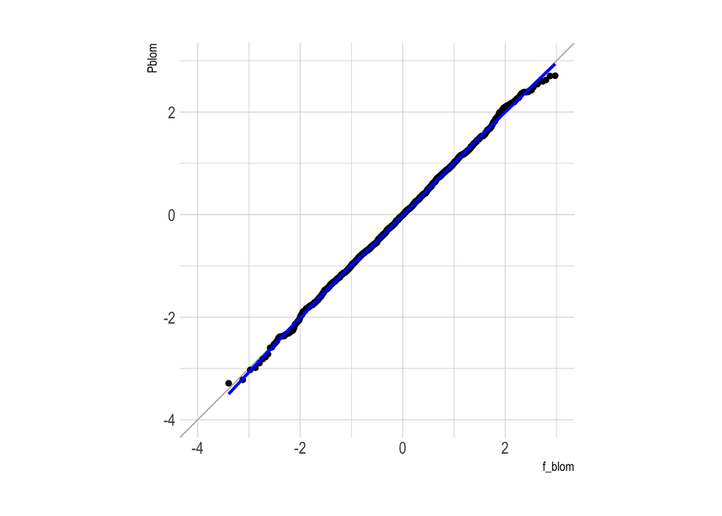

Original Blom score vs Predicted Blom score in norming sample

The cubic splines using the same knots were recreated in the full HRS sample and were used to predict the blom transformed factor score.

# Normalization of factor scores

The factor scores were normalized by regressing the predicted blom score on the demographic variables described above in the norming sample. Two way interactions between the variables were included.

Parameter estimates of the normalization regression in the norming sample

| term | estimate | std.error | statistic | p.value |
| --- | --- | --- | --- | --- |
| (Intercept) | 0.029 | 1.182 | 0.024 | 0.981 |
| spage1 | 0.002 | 0.018 | 0.123 | 0.902 |
| spage2 | −0.138 | 0.077 | −1.792 | 0.073 |
| spage3 | 0.297 | 0.174 | 1.709 | 0.088 |
| cfemale | −3.593 | 2.358 | −1.524 | 0.128 |
| cblack | −1.828 | 3.186 | −0.574 | 0.566 |
| chisp | −4.370 | 3.896 | −1.122 | 0.262 |
| cschlyrs | 0.233 | 0.445 | 0.523 | 0.601 |
| spage1:cfemale | 0.053 | 0.035 | 1.495 | 0.135 |
| spage1:cblack | 0.015 | 0.048 | 0.307 | 0.759 |
| spage1:chisp | 0.055 | 0.058 | 0.936 | 0.349 |
| spage1:cschlyrs | −0.001 | 0.007 | −0.143 | 0.886 |
| spage2:cfemale | −0.194 | 0.155 | −1.257 | 0.209 |
| spage2:cblack | −0.024 | 0.214 | −0.113 | 0.910 |
| spage2:chisp | −0.176 | 0.280 | −0.628 | 0.530 |
| spage2:cschlyrs | 0.010 | 0.030 | 0.344 | 0.731 |
| spage3:cfemale | 0.421 | 0.348 | 1.210 | 0.226 |
| spage3:cblack | 0.023 | 0.488 | 0.048 | 0.962 |
| spage3:chisp | 0.344 | 0.650 | 0.529 | 0.597 |
| spage3:cschlyrs | −0.033 | 0.067 | −0.499 | 0.618 |
| cfemale:cblack | 0.160 | 0.116 | 1.386 | 0.166 |
| cfemale:chisp | −0.082 | 0.139 | −0.585 | 0.559 |
| cfemale:cschlyrs | 0.023 | 0.014 | 1.622 | 0.105 |
| cblack:cschlyrs | 0.010 | 0.021 | 0.472 | 0.637 |
| chisp:cschlyrs | −0.084 | 0.018 | −4.708 | 0.000 |

## Plots of observed vs model implied blom scores

These are plots of the observed blom scores versus the model implied blom scores that adjusted for demographic characteristics.

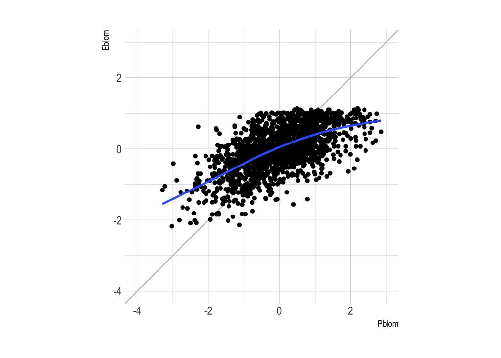

Predicted blom vs normalized blom in norming sample

The regression model was used to estimate the normalized blom scores in the full HRS sample.

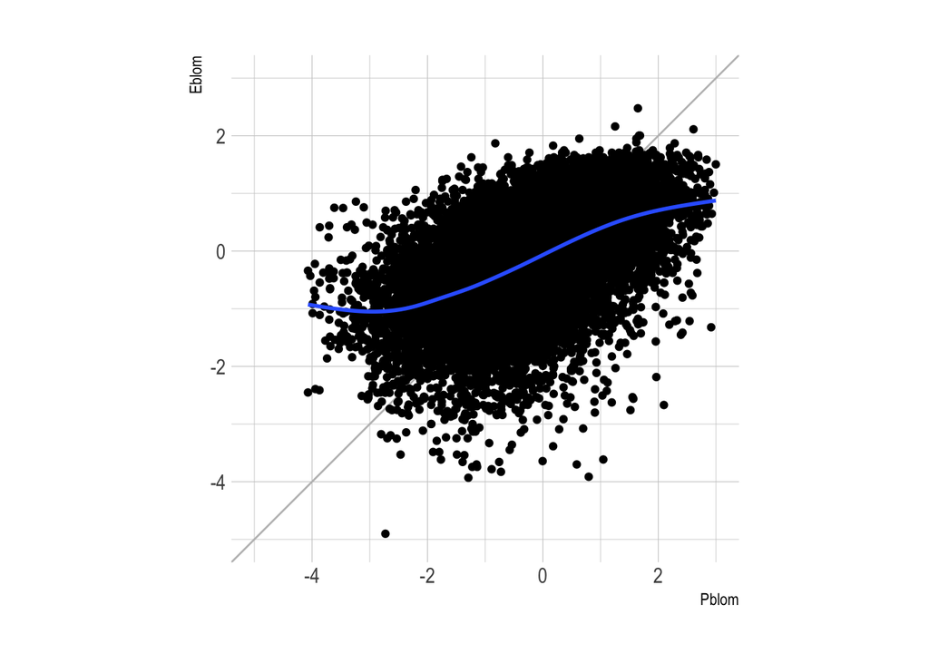

Predicted blom vs normalized blom in full HRS sample

# Transforming to T-scores

The normalized blom scores were transformed to a T-score using the following equation:

T= 50 + 10 * ((Predicted blom score - Normalized blom score)/(sd(predicted blom score)*sqrt(1-r2)))

The sd of the predicted blom score in the norming sample is: 0.999.

The adjusted model r2 is 0.389 .

Summary statistics of the factor score variables in the norming sample

| **Characteristic** | **N = 1,787**<sup>1</sup> |
| --- | --- |
| Predicted Blom score (model from HCAP normal sample) | 0.00 (1.00) |
| Unknown | 11 |
| Adjusted Blom score (from to HCAP normal sample) | 0.00 (0.63) |
| Unknown | 2 |
| T-scaled F score (from to HCAP normal sample) | 50 (10) |
| Unknown | 13 |

<sup>1</sup> Mean (SD)

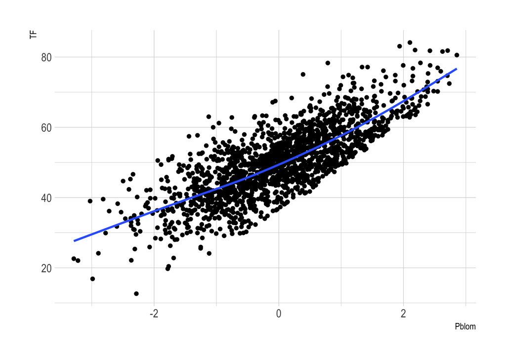

Predicted blom score vs T-score in norming sample

Summary statistics of the factor score variables in the full HRS sample

| **Characteristic** | **N = 20,912**<sup>1</sup> |
| --- | --- |
| Predicted Blom score (model from HCAP normal sample) | -0.20 (1.10) |
| Unknown | 942 |
| Adjusted Blom score (from to HCAP normal sample) | -0.16 (0.82) |
| Unknown | 91 |
| T-scaled F score (from to HCAP normal sample) | 49 (12) |
| Unknown | 1,030 |

<sup>1</sup> Mean (SD)

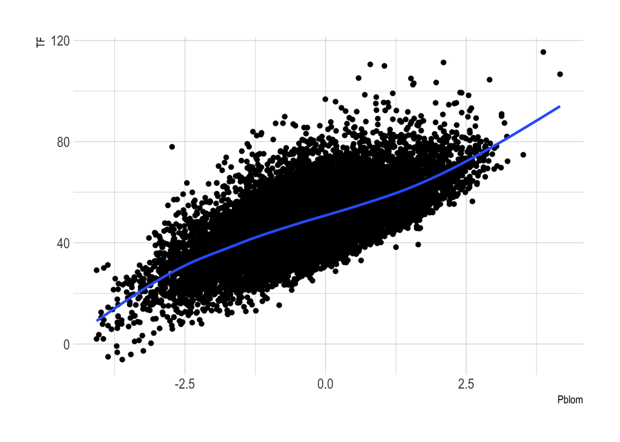

Predicted blom score vs T-score in the full HRS sample